# LAB04

Smirnov

04 12 2019

#K-Means Clustering (K-means) You have been asked to cluster all 50 U.S. states, including Washington D.C. and Puerto Rico, by mean household income and mean household electricity usage (both rounded by the integer). You have decided to use a k-means clustering algorithm.

Access the census data in the training2 database. Create a table with three columns: state, mean household income, and mean electricity usage.

Изначально все данные можно было получить из бд сделав такой запрос. Теперь все данные лежат в файле states.csv

## CREATE TABLE

library(‘RODBC’) ch <-odbcConnect(“Greenplum”,uid=“gpadmin”,case=“postgresql”,pwd=“changeme”) sqlDrop(ch,“income_elec_state”) sqlQuery(ch, “CREATE TABLE income_elec_state AS SELECT f.name AS state,round(avg(h.hinc),0) AS income,round(avg(h.elec),0) AS elec FROM fips AS f, housing_nodupes AS h WHERE h.state = f.code AND h.hinc IS NOT NULL AND h.hinc > 0 AND h.elec IS NOT NULL GROUP BY f.name;”) sqlColumns(ch,“income_state”) dataset <-as.matrix(sqlFetch(ch,“mystate”,rownames=“state”))

##LOAD Загрузим наши данные в dataset и посмотрит как они выгледят. Дальше нас будут интересовать график elec~income

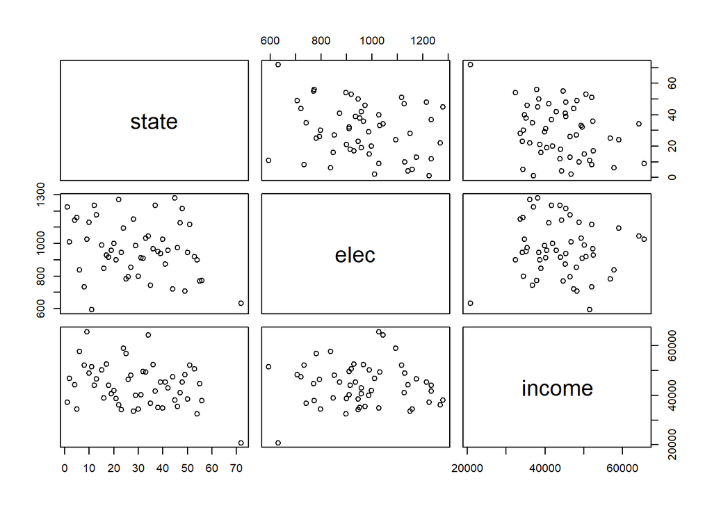

```r
dataset <- read.csv('states.csv')
plot(dataset)
```

1. Cluster the data and plot all 52 data points, along with the centroids. Mark all data points and centroids belonging to a given cluster with their own color. Here, let k=10.
2. Repeat step (a) several times. What can change each time you cluster the data? Why? How do you prevent these changes from occurring?

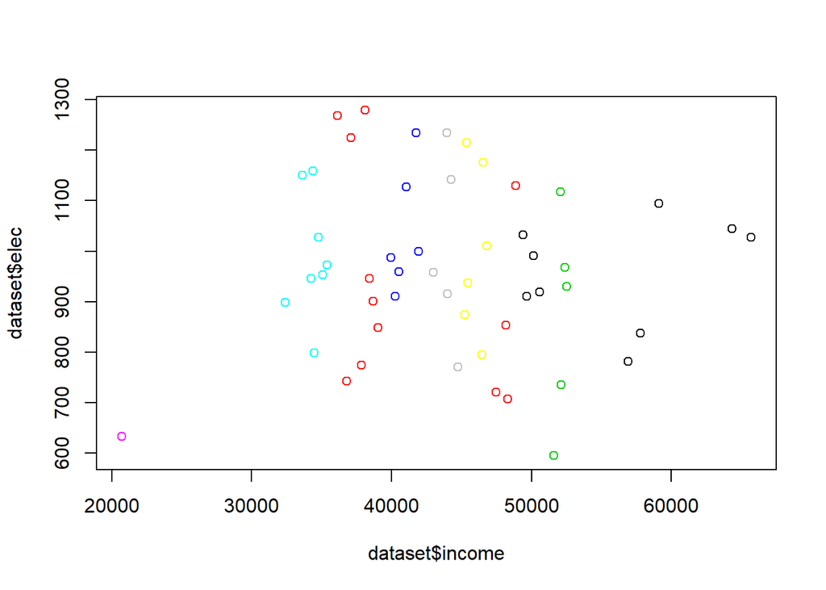

```r
clusters <- kmeans(dataset,centers=10)
plot(dataset$income,dataset$elec, col=clusters$cluster)
points(clusters$centers, col=1:10 , pch = 8, cex = 2)
```

## K Determination

3. Once you’ve accounted for the issues in the previous step, determine a reasonable value of k. Why would you suggest this value of k?
- Мы видим что для данной модели лучше выбрать 4-5 кластеров.

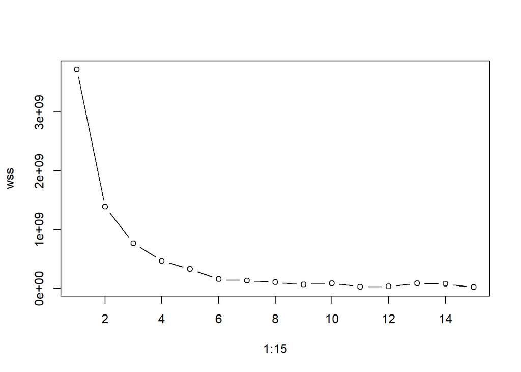

```r
mydata <- dataset
wss <- numeric(15)
for (i in 1:15) wss[i] <- sum(kmeans(mydata,centers=i)$withinss)
plot(1:15, wss, type="b")
```

## Scale

4. Convert the mean household income and mean electricity usage to a log10 scale and cluster this transformed dataset. How has the clustering changed? Why?

```r
log10_dataset<-dataset[,1:3]
log10_dataset[,2:3]<-log10(dataset[,2:3])
```

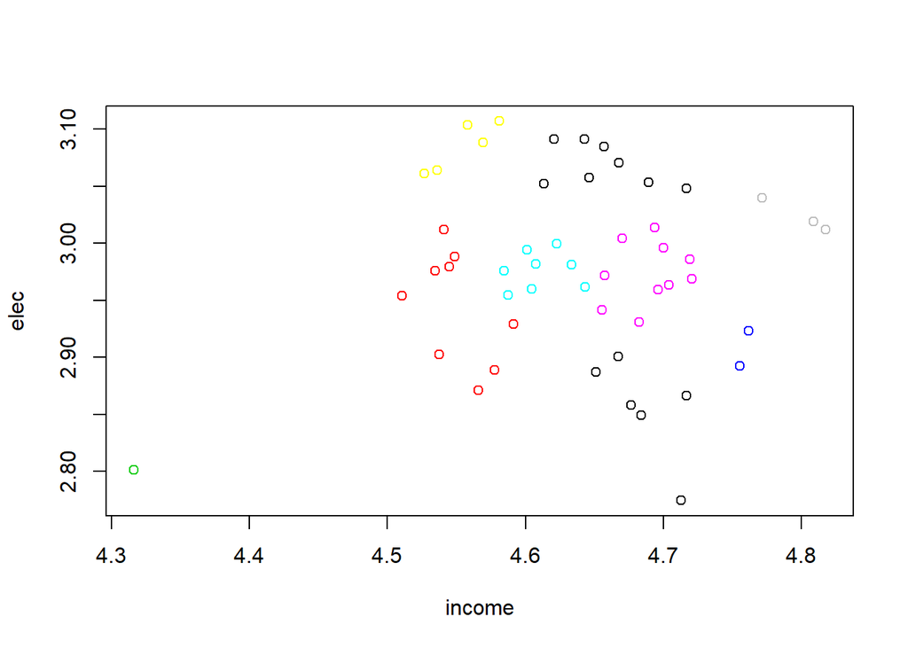

```r
log10_clusters <- kmeans(log10_dataset[,2:3],centers=10)
center_point <- log10_clusters$cluster[1:52]
log10_dataset<-cbind(log10_dataset,center_point)

plot(log10_dataset$income,log10_dataset$elec,col=log10_dataset$center_point,xlab="income",ylab="elec")
points(log10_clusters$centers,col=1:10,pch=8,cex=2)
```

## K Reevaluation

Переопределим значение кластеров.

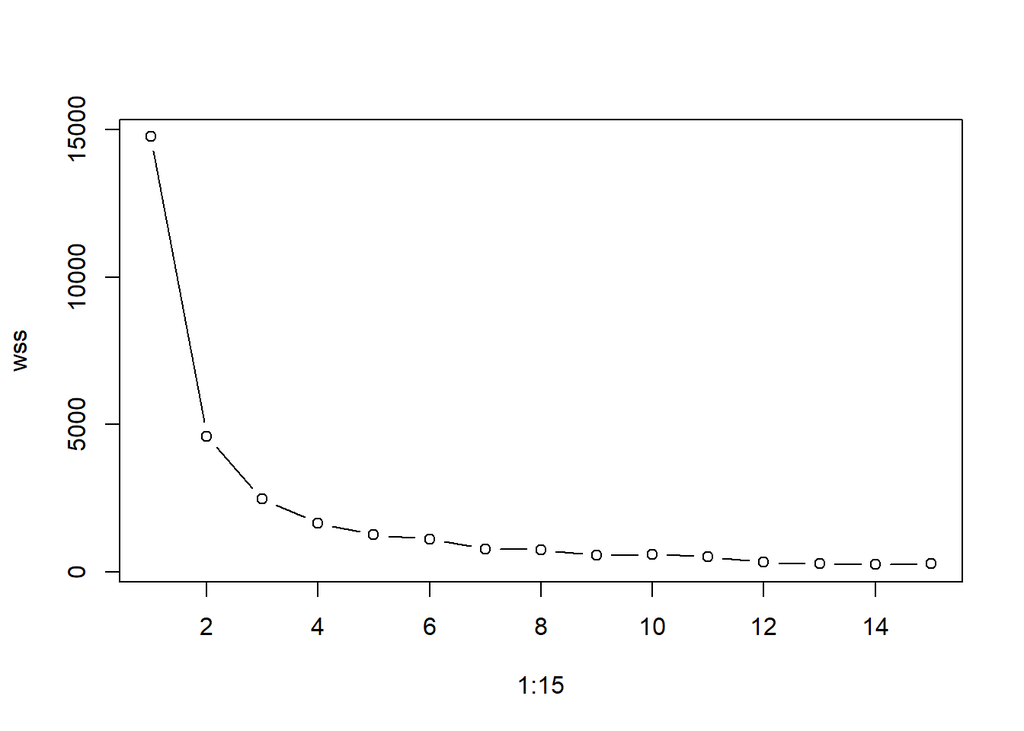

```r
mydata <- log10_dataset[,]
wss <- numeric(15)
for (i in 1:15) wss[i] <- sum(kmeans(mydata,centers=i)$withinss)
plot(1:15, wss, type="b")
```

## K Reevaluation II

6. Have you observed an outlier in the data? Remove the outlier and, once again, reevaluate your choice of k. Здесь мы удалим все выбросы.

```r
filtred_dataset <- log10_dataset[,1:3]
filtred_dataset<-filtred_dataset[filtred_dataset$state!='72',]
filtred_clusters <- kmeans(filtred_dataset[,],centers=10)
center_point <- filtred_clusters$cluster[1:51]
filtred_dataset<-cbind(filtred_dataset,center_point)
```

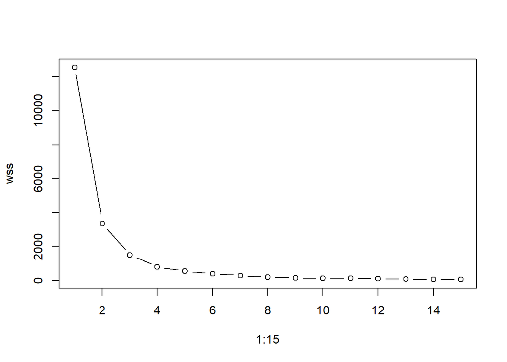

```r
mydata <- filtred_dataset[,1:2]
wss <- numeric(15)
for (i in 1:15) wss[i] <- sum(kmeans(mydata,centers=i)$withinss)
plot(1:15, wss, type="b")
```

## Maps and Code

1 step:

```r
require(maps)
map_order <- c('AL', 'AZ', 'AR', 'CA', 'CO', 'CT', 'DE', 'DC', 'FL',
               'GA', 'ID', 'IL', 'IN', 'IA', 'KS', 'KY', 'LA', 'ME',
               'MD', 'MA', 'MA', 'MA', 'MI', 'MI', 'MN', 'MS', 'MO',
               'MT', 'NE', 'NV', 'NH', 'NJ', 'NM', 'NY', 'NY', 'NY',
               'NY', 'NC', 'NC', 'NC', 'ND', 'OH', 'OK', 'OR', 'PA',
               'RI', 'SC', 'SD', 'TN', 'TX', 'UT', 'VT', 'VA', 'VA',
               'VA', 'WA', 'WA', 'WA', 'WA', 'WA', 'WV', 'WI', 'WY')
```

2 step:

```r
named_vector <- setNames(filtred_dataset$center_point, filtred_dataset$state)
map_color <- as.factor(named_vector[map_order])
```

2 step(as idea, doesn’t work well):

```r
map_color <- filtred_clusters$cluster[order(filtred_dataset$state)]
```

3 step:

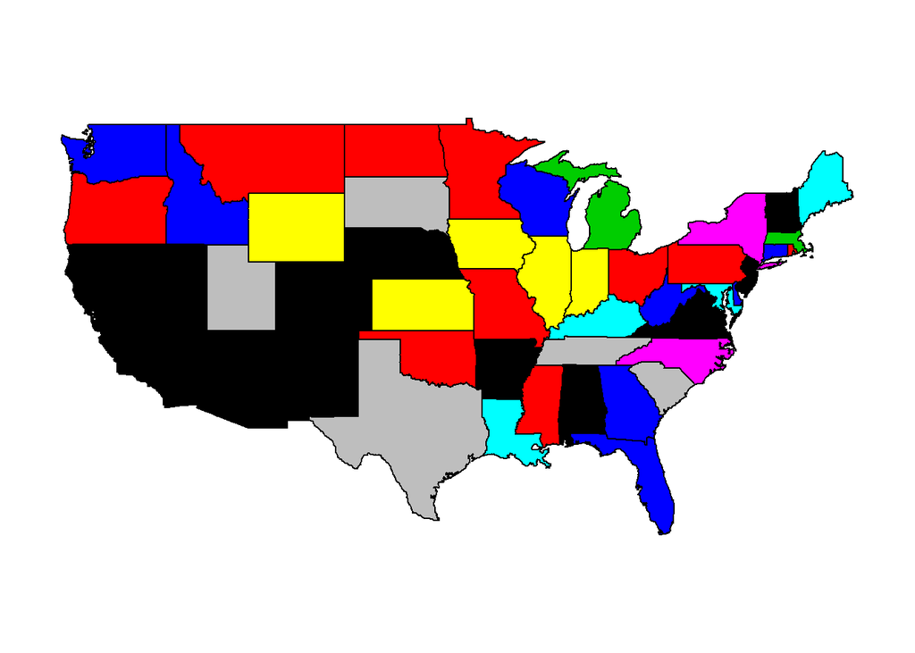

```r
maps::map('state',col = map_color,fill=T)
```

##Доп. задание от Дюмина

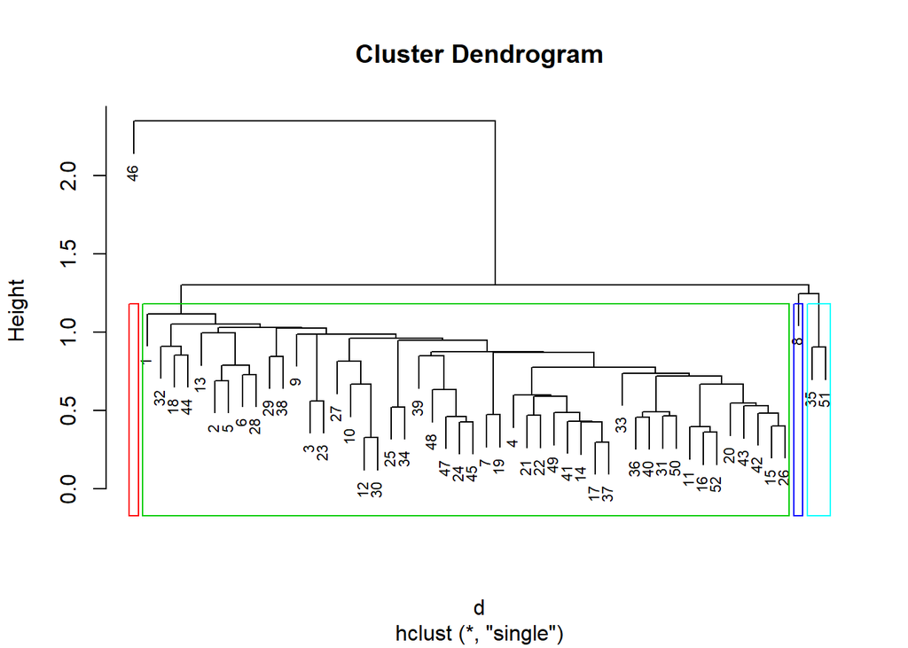

```r
d <- dist(scale(dataset), method = "euclidean")
cl <- hclust(d, method = "single")
plot(cl, cex = 0.7)
rect.hclust(cl, k = 4, border = 2:5)
```